# qPCR KK validation

Jade Benjamin-Chung

4/12/2018

#### Analysis of sensitivity and specificy using Bayesian Latent Class Models

#### Joint distribution of the results of a 2x2 table

- $T_1^+$ is the number of individuals who tested positive by Kato-Katz; $T_1^-$ is the number of individuals who tested negative by Kato-Katz
- $T_2^+$ is the number of individuals who tested positive by qPCR; $T_2^-$ is the number of individuals who tested negative by qPCR
- $X_{++}$ is the number of individuals who tested positive in both tests,
- $X_{+-}$ is the number of individuals who tested positive by Kato-Katz and negative by qPCR,
- and so on.
- $\pi$ is the true prevalence in the population
- $Se_1$ is the true sensitivity of Kato-Katz in the population; $Se_2$ is the true sensitivity of qPCR in the population
- $Sp_1$ is the true specificity of Kato-Katz in the population; $Sp_2$ is the true specificity of qPCR in the population

$(X_{++},X_{+-},X_{-+},X_{--}) \sim \text{Multi}(p_{++},p_{+-},p_{-+},p_{--},N_k)$

$p_{++}=P(T_i^+,T_j^+) = [Se_1Se_2+ cov(D_{12}^+)]\pi + [(1-Sp_1)(1-Sp_2) + cov(D_{12}^-)](1-\pi)$

$p_{+-}=P(T_i^+,T_j^-) = [Se_1(Se_2-1)- cov(D_{12}^+)]\pi + [(1-Sp_1)Sp_2 - cov(D_{12}^-)](1-\pi)$

$p_{-+}=P(T_i^-,T_j^+) = [(Se_1-1)Se_2- cov(D_{12}^+)]\pi + [Sp_1(1-Sp_2) - cov(D_{12}^-)](1-\pi)$

$p_{--}=P(T_i^-,T_j^-) = [(Se_1-1)(1-Se_2)+ cov(D_{12}^+)]\pi + [Sp_1Sp_2 - cov(D_{12}^-)](1-\pi)$

Conditional correlations between two test outcomes for infected individuals

$\rho_{D+} = \frac{covD^+}{\sqrt{Se_i(1-Se_i)Se_j(1-Se_j)}}$

Conditional correlations between two test outcomes for non-infected individuals

$\rho_{D-} = \frac{covD^-}{\sqrt{Sp_i(1-Sp_i)Sp_j(1-Sp_j)}}$

- $(Sp_1-1)(1-Sp_2)\leq cov(D_{12}^+)\leq \text{min}(Sp_1,Sp_2)-Sp_1Sp_2$
- $(Se_1-1)(1-Se_2)\leq cov(D_{12}^+)\leq \text{min}(Se_1,Se_2)-Se_1Se_2$
- Further assuming that the covariance is positive:
- $0\leq cov(D_{12}^+)\leq \text{min}(Sp_1,Sp_2)-Sp_1Sp_2$
- $0\leq cov(D_{12}^+)\leq \text{min}(Se_1,Se_2)-Se_1Se_2$

#### Priors

- $\pi \sim \text{beta}(\alpha_\pi,\beta_\pi)$; assume $\alpha = \beta =1$
- $Se_j \sim \text{beta}(\alpha_{Se_j},\beta_{Se_j}); j = (1,2)$; assume $\alpha = \beta =1$
- $Sp_j \sim \text{beta}(\alpha_{Sp_j},\beta_{Sp_j}); j = (1,2)$; assume $\alpha = \beta =1$
- $cov(D_{12}^+) \sim \text{unif}(\alpha_{cov(D_{12}^+)},\beta_{cov(D_{12}^+)})$, where $u_{se}=\text{min}(Se_1,Se_2)-Se_1Se_2$
- $cov(D_{12}^-) \sim \text{unif}(\alpha_{cov(D_{12}^-)},\beta_{cov(D_{12}^-)})$, where $u_{sp}=\text{min}(Sp_1,Sp_2)-Sp_1Sp_2$

#### Data

```r
rm(list=ls())
library(nimble)
library(reshape2)
library(ggplot2)
load("~/Dropbox/WASH-B-STH-Add-on/TFGH/Data/RData/qdata.RData")
```

```r
# define data for hookworm
hdata=qdata[!is.na(qdata$positive.Hw) & !is.na(qdata$hwkk),]
hw.x11=nrow(hdata[hdata$positive.Hw==1 & hdata$hwkk==1,])
hw.x10=nrow(hdata[hdata$positive.Hw==0 & hdata$hwkk==1,])
hw.x01=nrow(hdata[hdata$positive.Hw==1 & hdata$hwkk==0,])
hw.x00=nrow(hdata[hdata$positive.Hw==0 & hdata$hwkk==0,])
hw.n=sum(hw.x11,hw.x10,hw.x01,hw.x00)

hw.data=list(n=hw.n, x=c(hw.x11, hw.x10, hw.x01, hw.x00))
hw.data$x
```

```
## [1]  195   14  399 2181
```

#### Define Model

The following code chunk uses WinBUGS syntax to define the latent class model.

```r
lca.hw <- nimbleCode({
  # stochastic node
  x[1:4] ~ dmulti(p[1:4], n)

  # deterministic nodes
  p[1] <- pi*(Se1*Se2+covDp) + (1-pi)*((1-Sp1)*(1-Sp2)+covDn)
  p[2] <- pi*(Se1*(1-Se2)-covDp) + (1-pi)*((1-Sp1)*Sp2-covDn)
  p[3] <- pi*((1-Se1)*Se2-covDp) + (1-pi)*(Sp1*(1-Sp2)-covDn)
  p[4] <- pi*((1-Se1)*(1-Se2)+covDp) + (1-pi)*(Sp1*Sp2+covDn)

  us <- min(Se1,Se2) - Se1*Se2
  uc <- min(Sp1,Sp2) - Sp1*Sp2

  # prior values
  pi ~ dbeta(1,1)
  Se1 ~ dbeta(1,1)
  Sp1 ~ dbeta(1,1)
  Se2 ~ dbeta(1,1)
  Sp2 ~ dbeta(1,1)

  covDn ~ dunif(0, uc)
  covDp ~ dunif(0, us)
  rhoD <- covDp / sqrt(Se1*(1-Se1)*Se2*(1-Se2))
  rhoDc <- covDn / sqrt(Sp1*(1-Sp1)*Sp2*(1-Sp2))
})
```

I chose initial values as follows:

- `pi`: prevalence of hookworm by qPCR in our study
- `Se1`, `Sp1`: estimates for Kato-Katz from Nikolay et al.
- `Se2`, `Sp2`: estimates from Easton et al.
- `covDp`, `covDn`: I randomly sampled from the prior distribution defined above.
- `p`: For the probability of each count, I calculated the expected value using the assumptions defined above.
- `rhoD`, `rhoDc`: I arbitrarily chose 0.5, but am open to better ideas!

```r
# define initial values
set.seed(123)
hw.inits=list(pi=0.22, Se1=0.526, Se2=0.98, Sp1=0.986, Sp2=0.97,
              rhoD=0.5, rhoDc=0.5,
              p=c(0.526*0.22+0.98*0.22,
                  0.526*0.22+0.97*(1-0.22),
                  0.986*(1-0.22)+0.98*0.22,
                  0.986*(1-0.22)+0.97*(1-0.22)),
              covDp=runif(1,min=0,max=0.526-(0.526*0.98)),
              covDn=runif(1,min=0,max=0.97-(0.986*0.97)))
```

#### Display DAG

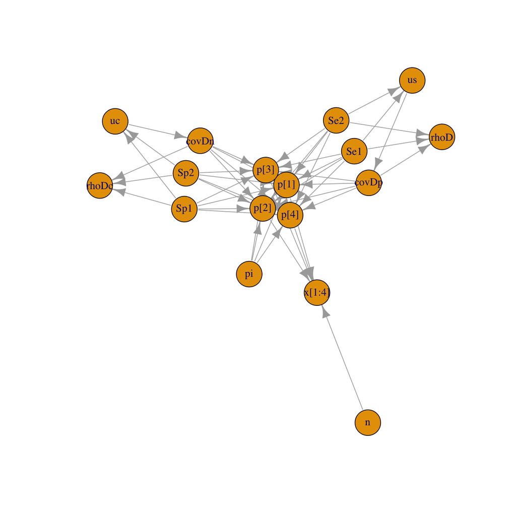

```r
# process BUGS model code
lca.model.hw <- nimbleModel(lca.hw, inits=hw.inits, data=hw.data)

# plot DAG
lca.model.hw$plotGraph()
```

#### Compile and configure Monte Carlo Markov Chain (MCMC)

Below I define the features of the MCMC model. The default sampling is Metropolis Hastings. WinBUGS (and thus all papers on this subject) uses Gibbs sampling, which is a special case of Metropolis Hastings. I’m not totally sure if this is different from Gibbs sampling in WinBUGS.

```r
c.lca.model.hw=compileNimble(lca.model.hw)
```

```
## compiling... this may take a minute. Use 'showCompilerOutput = TRUE' to see C++ compiler details.
```

```
## compilation finished.
```

```r
monitors=c("pi","Se1","Se2","Sp1","Sp2","rhoD", "rhoDc")
thin=100
lca.hw.Conf <- configureMCMC(lca.model.hw,
      monitors=monitors,
      thin=thin, print = TRUE)
```

```
## [1] RW sampler: pi
## [2] RW sampler: Se1
## [3] RW sampler: Sp1
## [4] RW sampler: Se2
## [5] RW sampler: Sp2
## [6] RW sampler: covDp
## [7] RW sampler: covDn
```

```r
hw.MCMC <- buildMCMC(lca.hw.Conf, enableWAIC = TRUE)
```

```
## Monitored nodes are valid for WAIC.
```

```r
C.hw.MCMC <- compileNimble(hw.MCMC, project=lca.model.hw)
```

```
## compiling... this may take a minute. Use 'showCompilerOutput = TRUE' to see C++ compiler details.
## compilation finished.
```

#### Run MCMC

```r
niter=1000000

# specify initial values for each chain
hw.inits=list(list(pi=0.22, Se1=0.526, Se2=0.98, Sp1=0.986, Sp2=0.97,
                   rhoD=0.5, rhoDc=0.5,
                   p=c(0.526*0.22+0.98*0.22,
                       0.526*0.22+0.97*(1-0.22),
                       0.986*(1-0.22)+0.98*0.22,
                       0.986*(1-0.22)+0.97*(1-0.22))),
              list(pi=0.5, Se1=0.5, Se2=0.5, Sp1=0.5, Sp2=0.5,
                   rhoD=0.5, rhoDc=0.5,
                   p=c(0.5,0.5,0.5,0.5)),
              list(pi=0.3, Se1=0.3, Se2=0.3, Sp1=0.3, Sp2=0.3,
                   rhoD=0.3, rhoDc=0.3,
                   p=c(0.3,0.3,0.3,0.3)),
              list(pi=0.4, Se1=0.4, Se2=0.4, Sp1=0.4, Sp2=0.4,
                   rhoD=0.4, rhoDc=0.4,
                   p=c(0.4,0.4,0.4,0.4)))
set.seed(12345)
mcmc.hw.out <- runMCMC(C.hw.MCMC, niter = niter, nchains = 4, inits=hw.inits)
```

```
## running chain 1...
```

```
## |-------------|-------------|-------------|-------------|
## |-------------------------------------------------------|
```

```
## running chain 2...
```

```
## |-------------|-------------|-------------|-------------|
## |-------------------------------------------------------|
```

```
## running chain 3...
```

```
## |-------------|-------------|-------------|-------------|
## |-------------------------------------------------------|
```

```
## running chain 4...
```

```
## |-------------|-------------|-------------|-------------|
## |-------------------------------------------------------|
```

```r
samples.hw.f=as.data.frame(do.call(rbind,mcmc.hw.out))
samples.hw.f$chain=as.factor(c(rep(1,niter/thin),
       rep(2,niter/thin),rep(3,niter/thin),
       rep(4,niter/thin)))

# convert samples to long format for plotting
samples.hw.l=melt(samples.hw.f,id.vars=c("chain"))

# plot history of each parameter
numMonitors=7
xseq=rep(rep(seq(1,niter/thin),numMonitors),4)
```

#### Plot the parameter estimates for each MCMC iteration

For each parameter with 1,000,000 iterations convergence isn’t great.

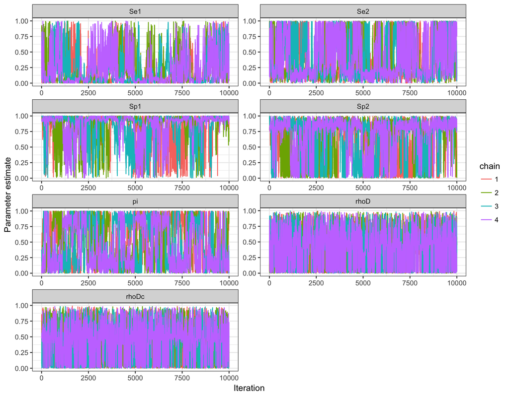

```r
ggplot(samples.hw.l, aes(x=xseq,y=value,color=chain))+
  geom_line()+facet_wrap(~variable, scales="free",ncol=2)+theme_bw()+
  xlab("Iteration")+ylab("Parameter estimate")
```

#### Plot the density of parameter estimates from MCMC

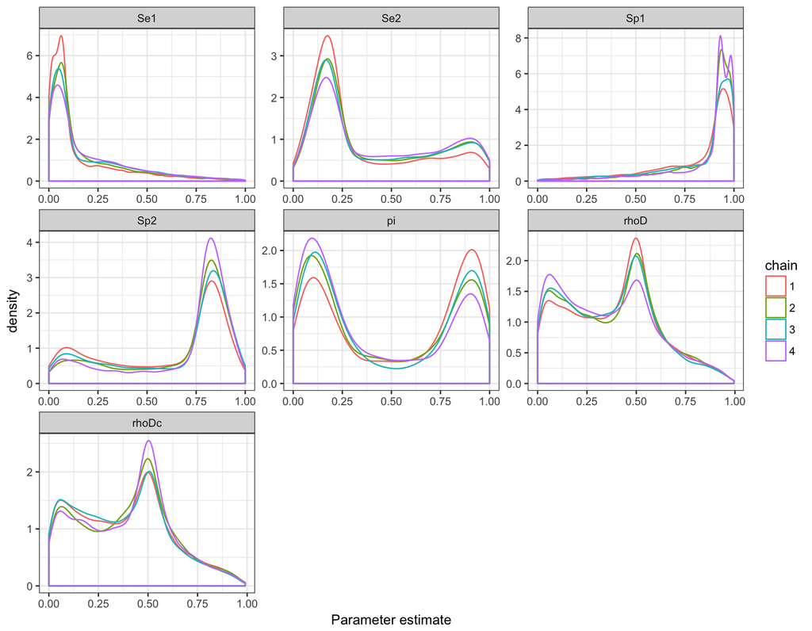

```r
ggplot(samples.hw.l, aes(x=value))+geom_density(aes(col=chain))+
  facet_wrap(~variable, scales="free")+theme_bw()+
  xlab("Kernal density")+xlab("Parameter estimate")
```

#### Plot autocorrelation for each parameter

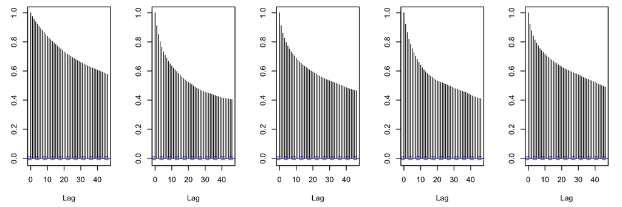

```r
par(mfrow = c(1, 5), mai = c(.6, .4, .1, .2))
acf(samples.hw.f[, "pi"])
acf(samples.hw.f[, "Se1"])
acf(samples.hw.f[, "Se2"])
acf(samples.hw.f[, "Sp1"])
acf(samples.hw.f[, "Sp2"])
```